# Rmarkdown自学笔记

ZJH

2023年3月22日至2023年05月29日

文档沟通篇

[figure not shown]

# 1 Markdown

## 1.1 什么是Markdown?

Markdown是一种轻量级标记语言，通过简单的标记语法，它可以使普通文本内容具有一定的格式。<sup>1</sup>

## 1.2 Markdown通用语法

1.标题  
Markdown中，在标题文字前书写不同数量的井号可以完成不同级别的标题，一个井号是一级标题，两个是二级标题，三个是三级标题，依次类推。  
标题行前面应该空一行，否则可能把某些偶然出现在行首的井号误认为标题行的标志。井号和一级标题之间建议保留一个字符的空格。  
还可以在文本下方添加任意数量的等号来标识一级标题，或破折号来标识二级标题。

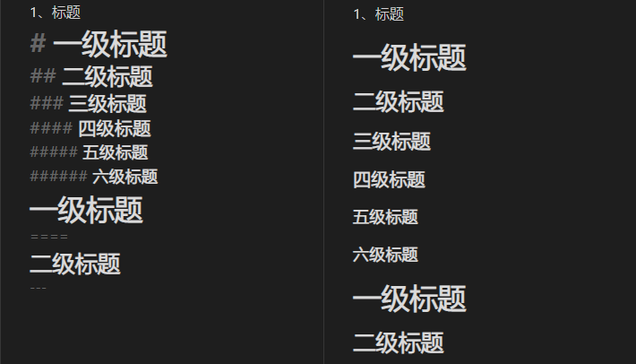

2.列表  
**无序列表**  
要创建无序列表，请在每个列表项前面添加破折号、星号或加号。缩进一个或多个列表项可创建嵌套列表。  
**有序列表**  
要创建有序列表，请在每个列表项前添加数字并紧跟一个英文句点。数字不必按数学顺序排列，但是列表应当以数字1起始。  
每个列表项可以输入多行，各行的内容最好左对齐，左对齐在使用文本格式时较易阅读，但不是必须的。两个列表项之间不要空行。

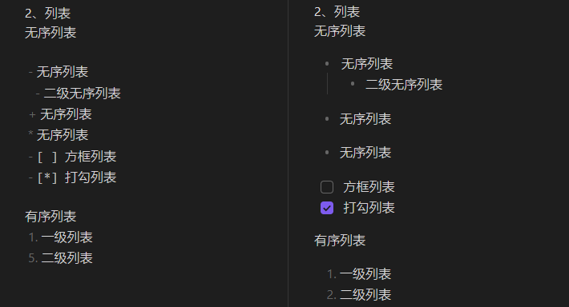

3.段落  
要创建段落，请使用空白行将一行或多行文本进行分隔。

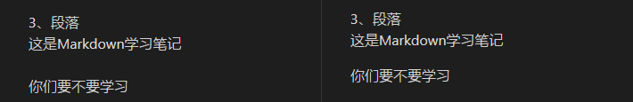

4.换行  
在一行的末尾添加两个或多个空格，然后按回车键，即可创建一个换行。  
5.强调  
**粗体**  
要加粗文本，请在单词或短语的前后各添加两个星号（asterisks）或下划线（underscores）。如需加粗一个单词或短语的中间部分用以表示强调的话，请在要加粗部分的两侧各添加两个星号（asterisks）。  
**斜体**  
要用斜体显示文本，请在单词或短语前后添加一个星号（asterisk）或下划线（underscore）。  
要同时用粗体和斜体突出显示文本，请在单词或短语的前后各添加三个星号或下划线。要加粗并用斜体显示单词或短语的中间部分，请在要突出显示的部分前后各添加三个星号，中间不要带空格。

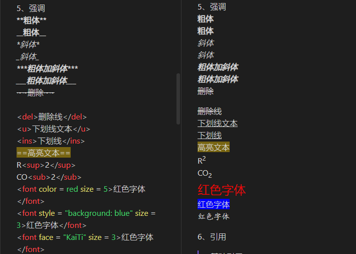

6.引用  
要创建块引用，请在段落前添加一个大于号。  
块引用可以包含多个段落。为段落之间的空白行添加一个大于号。  
块引用可以嵌套。在要嵌套的段落前添加一个大于号。

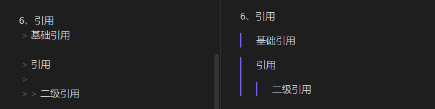

7.分割线  
要创建分隔线，请在单独一行上使用三个或多个星号、破折号或下划线，并且不能包含其他内容。

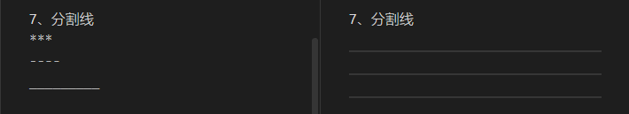

8.代码  
**行内代码**  
要将单词或短语表示为代码，请将其包裹在反引号中。  
**代码块**  
用三个连续的反向单撇号表示代码开头与代码结束，中间就会当作源程序代码处理。

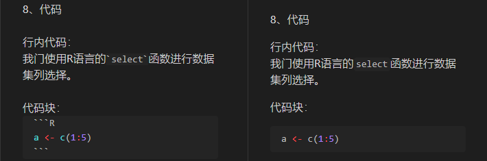

9.数学公式  
行内公式:前后各用一个$符号包裹公式。  
行间公式:前后各用两个$符号包裹公式。

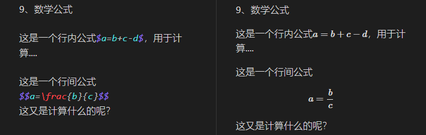

10.表格  
要添加表，请使用三个或多个连字符创建每列的标题，并使用管道分隔每列。您可以选择在表的任一端添加管道。

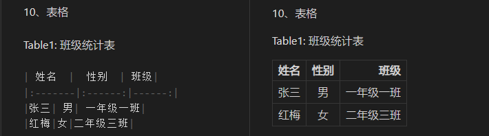

11.图片插入和链接  
图片： 要添加图像，请使用感叹号，然后在方括号增加替代文本，图片链接放在圆括号里，括号里的链接后可以增加一个可选的图片标题文本。

插入图片Markdown语法代码：`![图片描述](图片链接)`。

链接： 链接文本放在中括号内，链接地址放在后面的括号中，链接title可选。

超链接Markdown语法代码：`[超链接显示名](超链接地址)`。

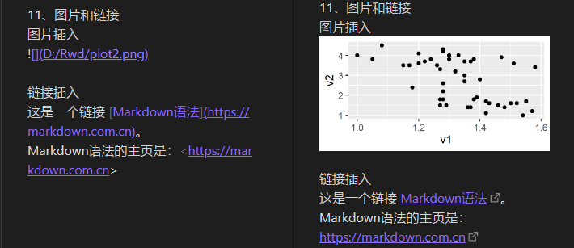

12.脚注  
要创建脚注参考，请在方括号内添加插入符号和标识符。标识符可以是数字或单词，但不能包含空格或制表符。标识符仅将脚注参考与脚注本身相关联在输出中，脚注按顺序编号。

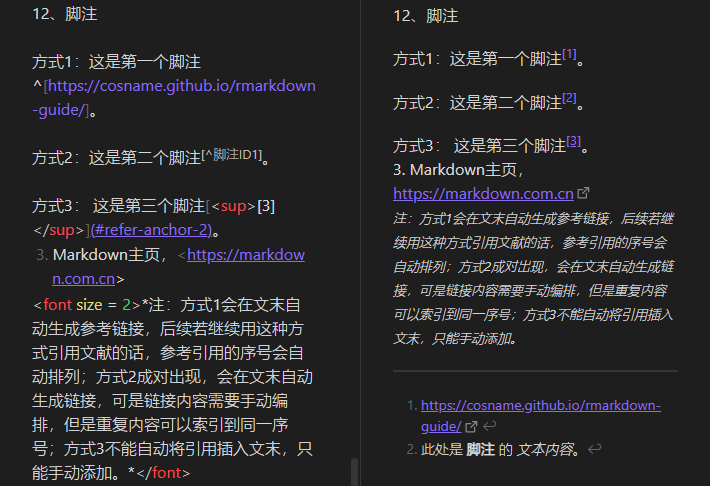

# 2 Rmarkdown

## 2.1 什么是Rmarkdown?

Rmarkdown是由谢益辉开发的在R语言环境中的markdown编辑工具，用rmarkdown撰写文章，既可以像⼀般的markdown编辑器一样编辑文本，也可以在rmarkdown中插入代码块，并将代码运行结果输出。  
Rmarkdown格式文件以.Rmd为扩展名，rmarkdown扩展包和knitr包一起为生成Rmd格式提供支持。  
Rmarkdown可实现文学化编程，即文档书写+编程，Rmarkdown将代码插入文档，在写研究报告或者论文时，这种方式集分析、思考、论述等过程于一体，形成的报告格式严谨，易复现，易共享。

Rmarkdown主要功能：

- 撰写数据分析报告
- 用交互笔记本记录学习过程
- 发表电子书和长篇文档
- 设计数据驱动的个人简历
- 建立个人网站和博客
- 创作演示文档和交互报表
- 用动态文档自动化报告发布

## 2.2 创建Rmarkdown文档

首先当然要保证安装R和Rstudio。  
其次在Rstudio中安装rmarkdown包。安装命令为install.packages(‘rmarkdown’)。  
新建文档：在Rstudio中，依次点File–New File–R Markdown…

[figure not shown]

作者可对title(标题)、author(作者)、dates(写作日期)进行自定义，可在Default Output Format选项自定义报告输出的格式。点击ok，新文档创建成功，文档以.Rmd为后缀。

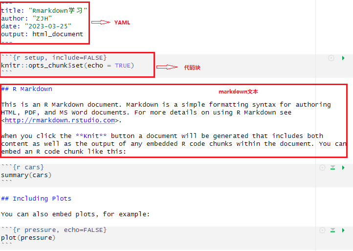

Rmarkdown提供了一个简单的示例文档，示例文档包括3部分：1.YAML、2.markdown⽂本、3.代码块。我们可以在示例文档的基础上进行修改以满足自己对输出文档的需求。<sup>2</sup>

1、YAML  
1到6行由一对三个减号包裹的部分为YAML，这部分通过若干“键:值”，对rmarkdown文档的性质进行定义，包括title、author、date、输出文档类型、文档主题、是否添加目录等。定义方式为冒号前指定键名， 冒号后指定对应的值，如：`title: Rmarkdown学习笔记`，表示定义文档题目为“Rmarkdown学习笔记”。  
**常见键值设置**  
`date: "r Sys.Date()"`：可以设置日期返回为今天。  
如：`date: "2022年1月1日至r format(Sys.time(),'%Y年%m月%d日')`，表示从之前某一时间点到今日。  
除过标题、作者、日期外，最重要的是指定输出格式，设定方法为：  
output:html_document、pdf_document、word_document，分别表示输出html、或者pdf、或者word文档。  
可以在output下设置二级选项，常见设置包括目录、主题等。

*其他二级选项*：

- toc: true：显示目录
- toc_float: true：浮动目录
- number_sections: true：添加标题编号
- code_folding: hide：代码折叠
- fig_width: 7, fig_height: 6：固定图片宽高
- fig_caption: true：添加图片标题
- df_print: kable：数据框输出表格样式
- highlight: tango：设置语法高亮
- theme: united：设置主题
- keep_md: true：保存中间.md文档
- citation_package: natbib：Latex 参考文献格式用natbib宏包
- reference_docx: “template.docx”：自定义word模板

2、markdown文本  
这部分是报告或论文的主体。文本大部分语法都遵循Markdown语法，少部分语法是Rmarkdown专用语法。

3、代码块  
位于一对反引号之间的部分即为代码块(chunk)，包含了报告可执行的代码。大括号后面的r指定了代码块语言类型，r代表是R语言，也可以替换为python等语言类型；语言名称的后面还可以附上代码块选项。代码块选项与代码块的关系就如同YAML元数据之于整个文档一样，用于指定该代码块的运行和输出设置。在自带文档中，setup是代码块的标签，`include = FALSE`指定了这个代码块的内容不会显示在输出中。  
创建代码块快捷键：Ctrl + Alt + I。

*常见代码块设置参数*：

- eval = FALSE：只显示代码，不运行代码
- echo = FALSE：不显示代码，只显示运行结果
- include = FALSE：运行代码，不显示代码和运行结果
- tidy = TRUE：整洁代码格式
- message = FALSE：不输出提示信息，比如包的载入信息
- warning = FALSE：不输出警告
- error = TRUE：忽略错误，继续编译文档
- collapse = TRUE：代码块结果放在一个文本块
- cache = TRUE：缓存运行结果，能加速后续再编译

## 2.3 输出文档

新建的Rmarkdown文档系统命名为untitled.Rmd(当你点击Rstudio左上角的保存按钮时可以自定义文档名称，并指定保存路径进行保存)，.Rmd文件是Rmarkdown的源文档，点击Rstudio右上角的Knit按钮或调用rmarkdown::render()函数后可进行文档编译并输出，Knit按钮本质上就是对rmarkdown包中render()函数的封装。点击Knit按钮后会跳出编译好的文档untitled.html，即为输出结果，HTML是Rmarkdown文档的默认输出格式，要输出其他格式，可在Rmarkdown文档YAML中进行设置。<sup>4</sup>

要想使用Rmarkdown输出PDF格式的文档，必须事先安装LaTeX。LaTeX有很多发行版，如MiKTex，MacTeX，TeX Live等，建议Rmarkdown的用户使用TinyTeX。TinyTex是谢益辉专为Rmarkdown开发的超轻量级的Latex环境。

安装TinyTeX命令：  
`install.packages("tinytex")`  
`tinytex::install_tinytex()`

我在自带模板的基础上进行了粗略修改，输出结果为：

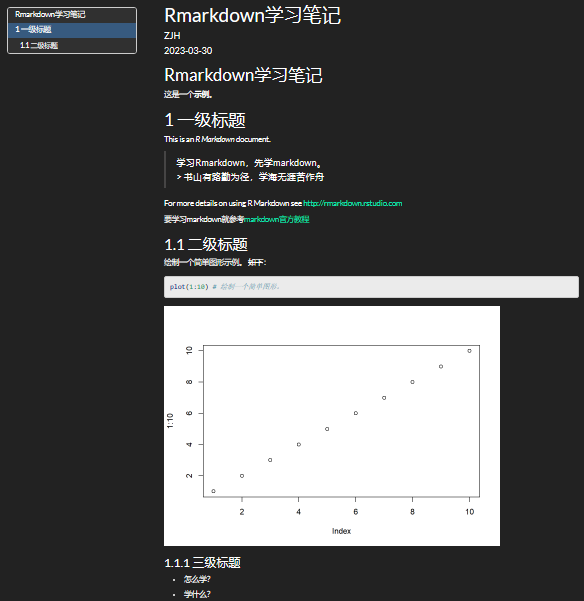

## 2.4 文档要素

### 2.4.1 文本

大部分遵从Markdown语法规则。下面以输出html为例，对文本部分进行梳理。

**1、题目**  
在YAML中定义，如`title:"论学习Rmarkdown的重要性"`。

**2、作者和单位**  
在YAML中定义，`author: "这是文档作者"`。  
若有多个作者，可用[]将多个作者包裹，作者间用逗号分隔。示例`author: ["author1","author2"]`，但是这样渲染后的结果每个作者占一行；也可以用短横线分隔多个作者。形式为`- name: 作者`  
作者单位：`affiliation: "这是文档作者的单位"`。

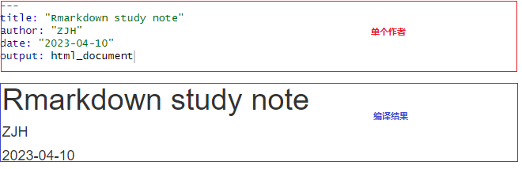

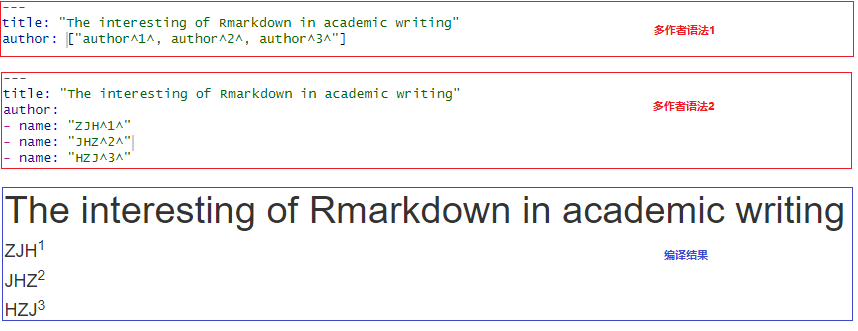

按照科技论文的格式进行编排试一下。

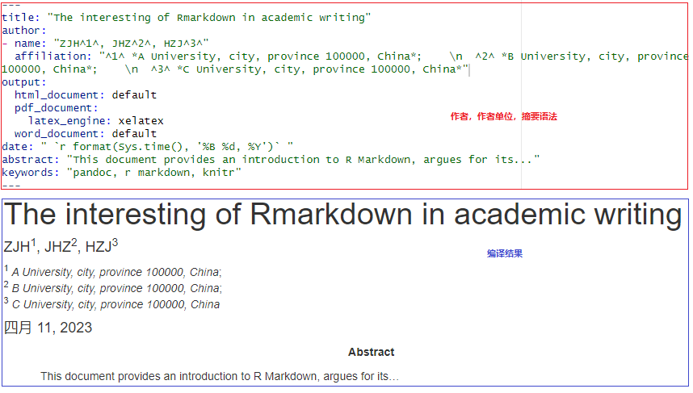

**3、目录**  
在YAML中定义，常见参数如下：

- toc: true 是所有输出格式的通用选项，用以自动生成目录。
- toc_depth: 4 通用选项，控制目录显示深度，即输出文档要显示的目录层级。
- toc_float(默认FALSE): true 适用于输出HTML格式文档。属性为true时，目录变为侧边栏，并固定在屏幕左侧。
- collapsed(默认true)：是否折叠二级标题以下的标题。
- smooth_scroll(默认true)：是否在鼠标点击目录时添加平滑滚动。
- number_sections(默认FALSE)：若为true，自动添加目录序号。

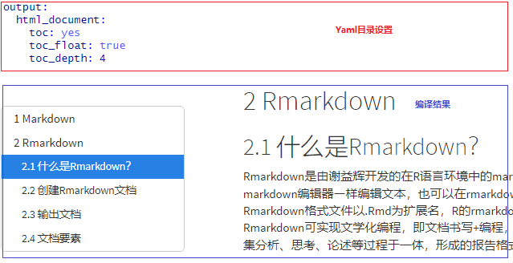

**4、更改全文格式**  
在YAML中定义：  
字号：fontsize: 字号，如8pt  
页边距：geometry: “left=2cm,right=2cm,top=2cm,bottom=2cm”  
主题：theme: 主题名称

**5、分页**  
分页：斜杠后面加newpage，`\newpage`。

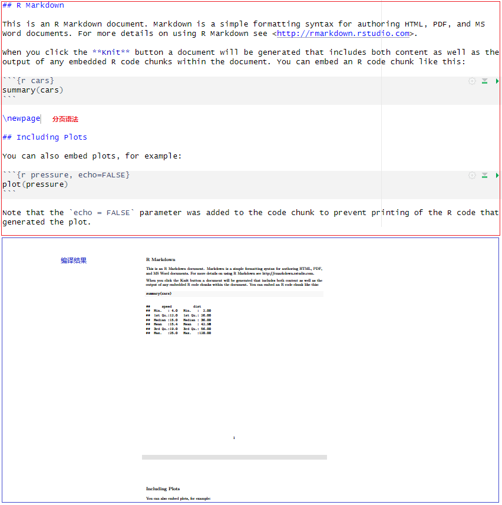

**6、分割线**  
如果只想插入一条水平的分割线而不分页，可以插入三个减号-–或者星号***。  
下面有一条分割线。

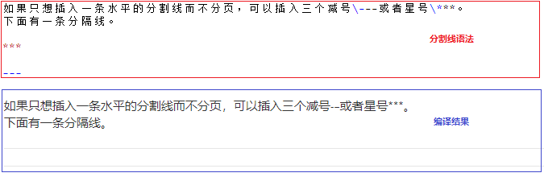

**7、换行和空行**  
换行：文字+至少2个空格+回车键  
示例：  
这是换行前的一行。

这是换行后的下一行。

空行：段落之间添加空行需要通过`</br>`完成。<sup>5</sup>  
示例：  
这是空行前的一行。  
这是空行后的一行。

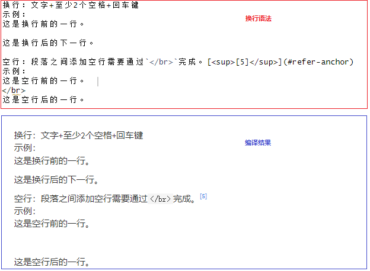

**8、字体渲染**  
改变字体及颜色示例

以上设置的代码为`<font face="楷体" color=green size=5>改变字体及颜色示例</font>`，face定义字体，color定义字体颜色，size定义字体大小。

改变字体及颜色的另一种方式

以上代码为`<span style="color:blue" face="黑体" size=18>改变字体及颜色的另一种方式</span>`

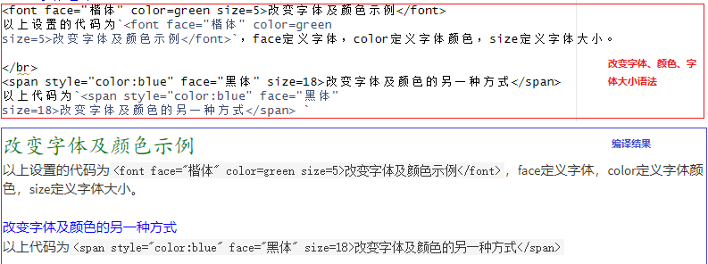

**9、公式**
行内公式：公式前后各一个$符号。
行间公式：公式前后各两个$$符号。
公式内上标：`^2`
公式内下标：`_2`
分数：`\frac{分子}{分母}`，或`分子 \over 分母`
加减乘除：`+`，`-`，`\times`，`\div`。
一个示例：
$$y=\frac {a}{b}+cx^2-(d\times e)
\div f_2$$

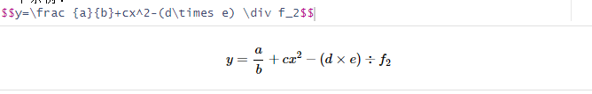

**10、上下标及删除线**  
上标：前后各一个`^`。`^上标^`  
下标：前后各一个`~`。`~下标~`  
删除线：前后各两个`~`。`~~删除线~~`  
一个示例：这是<sup>上标</sup>示例，这是<sub>下标</sub>示例，这是删除线示例。

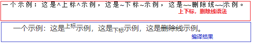

**11、首行缩进**  
方式1：  
缩进几个空格就添加几个`&emsp;`。

这是未缩进的文本；  
这是首行缩进3个空格的示例文本。

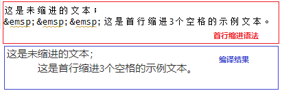

方式2：  
段落前加|，后面空格进行缩进。

this is a example  
this is another example  
this is the third example

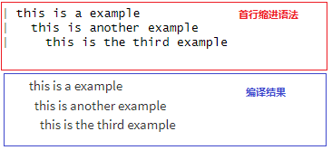